# BIOS 667 - Lecture 19: Transition (Markov) Models

Fitzmaurice, Laird & Ware (2011) - Applied Longitudinal Data Analysis

Naim Rashid

## Lecture Objectives

- Understand **transition models** as an alternative to marginal and mixed models
- Define **Markov models** and their application to longitudinal data
- Fit **first-order transition models** for binary outcomes
- Interpret regression coefficients conditional on **previous responses**
- Compare transition, marginal, and mixed model interpretations

**Provenance: instructor extension**

Transition (Markov) models are an **instructor extension**, FLW 1st-ed (2004) Ch. 10. The 2nd-ed (2011) text has **no dedicated transition-models chapter**; the marginal/mixed/transition trichotomy is framed in FLW 2nd-ed Ch. 12 (Marginal Models). We include transition models here to complete that trichotomy.

## Roadmap

| Part | Topic |
| --- | --- |
| I | Introduction: Three Model Families |
| II | Markov Models and Transition Probabilities |
| III | First-Order Transition Models |
| IV | Estimation and Inference |
| V | Extensions and Higher-Order Models |
| VI | Comparison with Marginal and Mixed Models |

## Part I: Introduction

## Three Approaches to Longitudinal Data

| Model Family | Conditions On | $\beta$ Interpretation |
| --- | --- | --- |
| **Marginal** | Covariates only | Population-average |
| **Mixed** | Random effects $b_i$ | Subject-specific |
| **Transition** | Previous responses $Y_{i,j-1}$ | Conditional on past |

All three can be valid for the same data; the choice depends on the scientific question.

## When to Use Transition Models

Transition models are natural when:

- The **previous outcome** directly influences the current outcome
- Interest lies in **state changes** over time
- Data represent a **stochastic process** (e.g., disease progression)

**Examples:** relapse/remission, employment status, symptom presence/absence

## Motivating Example: Depression Study

Consider a longitudinal study of depression where patients are assessed monthly.

**Question:** Does current depression status depend on:

1. Covariates (treatment, age)?
2. Depression status at the previous visit?

A transition model addresses both simultaneously.

## Check Your Understanding: Part I

**Quick Self-Check**

1. **Model Selection:** A researcher wants to estimate the population-average effect of a new drug on blood pressure. Should they use a marginal, mixed, or transition model?
2. **Research Question Match:** You want to know: “Given that a patient was depressed last month, what is the probability they are depressed this month?” Which model type answers this question?
3. **When NOT to Use Transition Models:** A study measures height in children annually. Would a transition model be appropriate? Why or why not?

**Answers**

1. **Marginal model (GEE)** - The research question is about population-average effects, not conditional on individual history or subject-specific effects.
2. **Transition model** - This question explicitly conditions on the previous state (“given that a patient was depressed last month”), which is exactly what transition models address.
3. **No** - Height is a continuous, monotonically increasing outcome where the previous value does not meaningfully “cause” the current value in a stochastic sense. A mixed model capturing individual growth trajectories would be more appropriate. Transition models are best for discrete states or outcomes where state dependence is meaningful (e.g., relapse/remission).

## Part II: Markov Models

## Markov Processes

A **Markov chain** is a stochastic process where the future state depends only on the current state, not the full history.

**First-order Markov property:**

$$P(Y_{ij} | Y_{i1}, \ldots, Y_{i,j-1}, X_i) = P(Y_{ij} | Y_{i,j-1}, X_{ij})$$

The past influences the present only through the most recent observation.

## Transition Probabilities

For binary outcomes, define the **transition probability** (subject $i$, occasion $j$):

$$\pi_{jk} = P(Y_{ij} = 1 \mid Y_{i,j-1} = k), \quad k \in \{0, 1\}$$

| From State | To State | Probability |
| --- | --- | --- |
| 0 (healthy) | 1 (diseased) | $\pi_{j0}$ |
| 1 (diseased) | 1 (diseased) | $\pi_{j1}$ |

## Transition Matrix

The **transition matrix** summarizes all state changes:

$$\mathbf{P} = \begin{pmatrix}
1 - \pi_{j0} & \pi_{j0} \\
1 - \pi_{j1} & \pi_{j1}
\end{pmatrix}$$

Row $k$ gives probabilities of moving from state $k$ to each possible state.

## Example: 2-State Health Model

```r
# Hypothetical transition probabilities
pi_0 <- 0.15  # P(sick | was healthy)
pi_1 <- 0.70  # P(sick | was sick)

P <- matrix(c(1 - pi_0, pi_0,
              1 - pi_1, pi_1),
            nrow = 2, byrow = TRUE,
            dimnames = list(c("Healthy", "Sick"),
                            c("Healthy", "Sick")))
P
```

## Example: 2-State Health Model

```
        Healthy Sick
Healthy    0.85 0.15
Sick       0.30 0.70
```

## Visualizing Transitions

```r
suppressPackageStartupMessages({
  library(ggplot2)
  library(dplyr)
  library(tidyr)
})

trans_df <- as.data.frame(P) |>
  tibble::rownames_to_column("From") |>
  pivot_longer(-From, names_to = "To", values_to = "Probability")

ggplot(trans_df, aes(To, From, fill = Probability)) +
  geom_tile(color = "white", linewidth = 1) +
  geom_text(aes(label = round(Probability, 2)), size = 6) +
  scale_fill_gradient(low = "white", high = "steelblue") +
  labs(title = "Transition Probability Matrix",
       x = "To State", y = "From State") +
  theme_minimal(base_size = 14) +
  theme(legend.position = "none")
```

## Visualizing Transitions

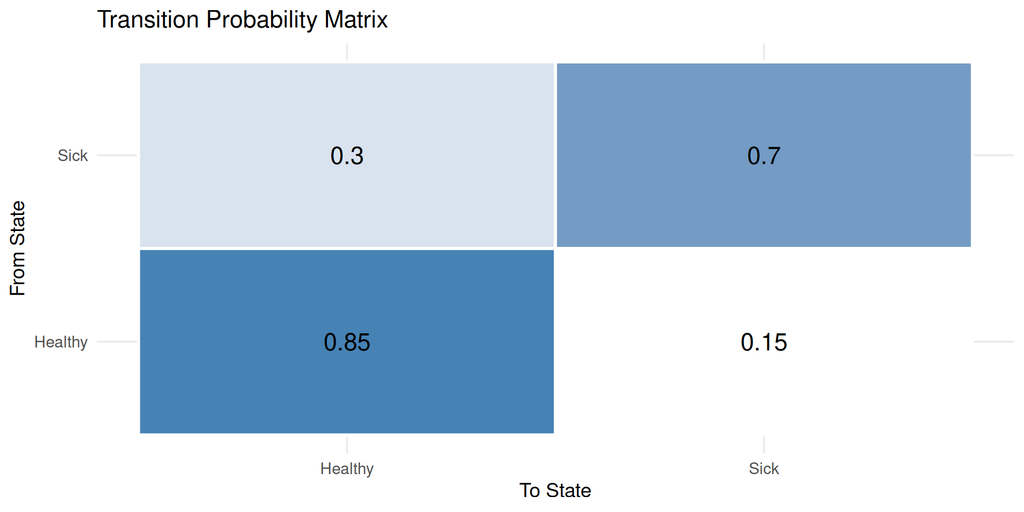

## Stationary Distribution

If transitions are time-homogeneous, the **stationary distribution** $\pi^*$ satisfies:

$$\pi^* = \pi^* \mathbf{P}$$

This gives the long-run proportion in each state.

```r
# Solve for stationary distribution
# pi = pi * P means (I - P')pi = 0
# Add constraint: sum(pi) = 1
A <- rbind(t(diag(2) - P), c(1, 1))
b <- c(0, 0, 1)
pi_star <- qr.solve(A, b)
names(pi_star) <- c("Healthy", "Sick")
round(pi_star, 3)
```

## Stationary Distribution

```
Healthy    Sick
  0.667   0.333
```

## Check Your Understanding: Part II

**Quick Self-Check**

1. **Transition Matrix:** Given a transition matrix where P(Sick|Healthy) = 0.2 and P(Sick|Sick) = 0.6, what is P(Healthy|Sick)?
2. **Markov Property:** Patient A has been healthy for 5 visits. Patient B has been healthy for 1 visit. According to the first-order Markov property, how do their probabilities of being sick next visit compare?
3. **Stationary Distribution:** If a disease has P(Disease|Healthy) = 0.1 and P(Disease|Disease) = 0.9, will the long-run prevalence be closer to 10% or 50%?

**Answers**

1. **P(Healthy|Sick) = 0.4** - Each row of the transition matrix must sum to 1. If P(Sick|Sick) = 0.6, then P(Healthy|Sick) = 1 - 0.6 = 0.4.
2. **They are the same!** The first-order Markov property says the future depends ONLY on the current state, not the history. Both patients are currently Healthy, so both have the same transition probability to Sick.
3. **Closer to 50%** - Solve $\pi = \pi P$: $\pi_{disease} = \pi_{healthy} \times 0.1 + \pi_{disease} \times 0.9$. With $\pi_{healthy} + \pi_{disease} = 1$, we get $\pi_{disease} = 0.5$. The high persistence in the disease state (0.9) keeps people sick once they become sick.

## Part III: First-Order Transition Models

## The Basic Transition Model

For binary $Y_{ij}$, model the conditional probability:

$$\text{logit}\, P(Y_{ij} = 1 | Y_{i,j-1}, X_{ij}) = \beta_0 + \beta_1 Y_{i,j-1} + X_{ij}\gamma$$

- $\beta_0$: baseline log-odds when $Y_{i,j-1} = 0$
- $\beta_1$: effect of previous positive response (dependence parameter)
- $\gamma$: covariate effects, conditional on previous response

## Interpretation of $\beta_1$

The coefficient $\beta_1$ captures **state dependence**:

- $\beta_1 > 0$: positive autocorrelation (persistence)
- $\beta_1 = 0$: no first-order state dependence (responses conditionally independent given covariates; still a valid Markov model)
- $\beta_1 < 0$: negative autocorrelation (alternating states)

$$\text{OR} = e^{\beta_1}$$

## Simulate Transition Data

```r
set.seed(667)

N <- 200      # subjects
n_times <- 6  # observations per subject

# Subject-level covariates
trt <- rep(rbinom(N, 1, 0.5), each = n_times)
id <- rep(1:N, each = n_times)
time <- rep(0:(n_times-1), N)

# Initialize
y <- numeric(N * n_times)

# Parameters
beta_0 <- -1.5   # baseline log-odds
beta_1 <- 1.8    # lag effect (strong positive dependence)
gamma_trt <- -0.6  # treatment effect
gamma_time <- 0.1  # time effect

# Generate first observation (use marginal model)
first_idx <- seq(1, N * n_times, by = n_times)
p_first <- plogis(beta_0 + gamma_trt * trt[first_idx])
y[first_idx] <- rbinom(N, 1, p_first)

# Generate subsequent observations using transition model
for (i in 1:N) {
  for (j in 2:n_times) {
    idx <- (i - 1) * n_times + j
    idx_prev <- idx - 1
    lp <- beta_0 + beta_1 * y[idx_prev] + gamma_trt * trt[idx] + gamma_time * time[idx]
    y[idx] <- rbinom(1, 1, plogis(lp))
  }
}

dat <- data.frame(
  id = factor(id),
  time = time,
  trt = factor(trt, labels = c("Control", "Treatment")),
  y = y
)

head(dat, 12)
```

## Simulate Transition Data

```
   id time     trt y
1   1    0 Control 0
2   1    1 Control 0
3   1    2 Control 0
4   1    3 Control 1
5   1    4 Control 0
6   1    5 Control 0
7   2    0 Control 0
8   2    1 Control 0
9   2    2 Control 1
10  2    3 Control 1
11  2    4 Control 1
12  2    5 Control 0
```

## Create Lagged Response

```r
# Add lagged response within each subject
dat <- dat |>
  group_by(id) |>
  mutate(y_lag = lag(y, 1)) |>
  ungroup()

# Remove first observation (no lag available)
dat_model <- dat |> filter(!is.na(y_lag))

head(dat_model, 12)
```

## Create Lagged Response

```
# A tibble: 12 × 5
   id     time trt           y y_lag
   <fct> <int> <fct>     <dbl> <dbl>
 1 1         1 Control       0     0
 2 1         2 Control       0     0
 3 1         3 Control       1     0
 4 1         4 Control       0     1
 5 1         5 Control       0     0
 6 2         1 Control       0     0
 7 2         2 Control       1     0
 8 2         3 Control       1     1
 9 2         4 Control       1     1
10 2         5 Control       0     1
11 3         1 Treatment     0     0
12 3         2 Treatment     0     0
```

## Fit First-Order Transition Model

```r
fit_trans <- glm(y ~ y_lag + trt + time,
                 data = dat_model,
                 family = binomial(link = "logit"))

summary(fit_trans)
```

## Fit First-Order Transition Model

```
Call:
glm(formula = y ~ y_lag + trt + time, family = binomial(link = "logit"),
    data = dat_model)

Coefficients:
             Estimate Std. Error z value Pr(>|z|)
(Intercept)  -1.43159    0.19939  -7.180 6.97e-13 ***
y_lag         1.80266    0.16198  11.129  < 2e-16 ***
trtTreatment -0.54052    0.15153  -3.567 0.000361 ***
time          0.11067    0.05457   2.028 0.042568 *
---
Signif. codes:  0 '***' 0.001 '**' 0.01 '*' 0.05 '.' 0.1 ' ' 1

(Dispersion parameter for binomial family taken to be 1)

    Null deviance: 1233.4  on 999  degrees of freedom
Residual deviance: 1061.8  on 996  degrees of freedom
AIC: 1069.8

Number of Fisher Scoring iterations: 4
```

## Coefficient Interpretation

```r
suppressPackageStartupMessages(library(broom))

tidy_trans <- tidy(fit_trans, conf.int = TRUE, exponentiate = TRUE)
tidy_trans |>
  mutate(across(where(is.numeric), ~round(., 3))) |>
  select(term, estimate, conf.low, conf.high, p.value)
```

## Coefficient Interpretation

```
# A tibble: 4 × 5
  term         estimate conf.low conf.high p.value
  <chr>           <dbl>    <dbl>     <dbl>   <dbl>
1 (Intercept)     0.239    0.161     0.351   0
2 y_lag           6.07     4.43      8.36    0
3 trtTreatment    0.582    0.432     0.784   0
4 time            1.12     1.00      1.24    0.043
```

## Key Findings

| Parameter | Estimate | Interpretation |
| --- | --- | --- |
| `y_lag` | OR = 6.07 | Strong positive dependence |
| `trtTreatment` | OR = 0.58 | Treatment reduces odds |
| `time` | OR = 1.12 | Slight increase over time |

**Interpretation:** Given the previous response, treatment reduces the odds of a positive response at the current time.

## Recipe Card: Fitting First-Order Transition Models

**Step-by-Step Guide**

**Step 1: Prepare the Data**

```r
# Create lagged response within each subject
dat <- dat |>
  group_by(id) |>
  mutate(y_lag = lag(y, 1)) |>
  ungroup()

# Remove first observation (no lag available)
dat_model <- dat |> filter(!is.na(y_lag))
```

**Step 2: Fit the Model**

```r
# Standard GLM with lagged response as covariate
fit <- glm(y ~ y_lag + treatment + time,
           data = dat_model,
           family = binomial(link = "logit"))
```

**Step 3: Get Robust Standard Errors**

```r
library(sandwich)
library(lmtest)
coeftest(fit, vcov = vcovCL(fit, cluster = dat_model$id))
```

**Step 4: Alternative - Use GEE**

```r
library(geepack)
fit_gee <- geeglm(y ~ y_lag + treatment + time,
                  data = dat_model,
                  id = id,
                  family = binomial,
                  corstr = "independence")
```

## Interpreting Transition Model Output

**How to Read Your Results**

**The $\beta_1$ (y_lag) coefficient:**

- $\beta_1 > 0$ (OR > 1): **Persistence** - being in state 1 increases odds of staying in state 1
- $\beta_1 < 0$ (OR < 1): **Alternation** - being in state 1 decreases odds of staying in state 1
- $\beta_1 = 0$ (OR = 1): No state dependence (observations are independent given covariates)

**Treatment effect interpretation:**

Unlike marginal models, the treatment effect $\gamma$ is **conditional on the previous state**:

> “Among subjects who were [in state k] at the previous visit, treatment reduces/increases the odds of being [in state 1] by [OR]”

This is NOT the same as the population-average treatment effect from GEE!

**When to trust your model:**

1. Check if first-order is sufficient (test second lag)
2. Verify robust SEs are similar to model-based SEs
3. Examine residuals and predicted probabilities

## Predicted Transition Probabilities

```r
newdat <- expand.grid(
  y_lag = c(0, 1),
  trt = c("Control", "Treatment"),
  time = 3  # mid-study
)

newdat$prob <- predict(fit_trans, newdata = newdat, type = "response")

ggplot(newdat, aes(x = factor(y_lag), y = prob, fill = trt)) +
  geom_bar(stat = "identity", position = "dodge", width = 0.6) +
  labs(title = "Transition Probabilities by Treatment",
       x = "Previous Response (Y_lag)",
       y = "P(Y = 1 | Y_lag, Treatment)",
       fill = "Group") +
  scale_y_continuous(limits = c(0, 1)) +
  theme_minimal(base_size = 14)
```

## Predicted Transition Probabilities

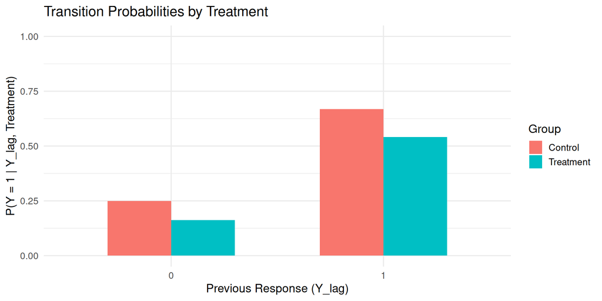

## Observed Transition Frequencies

```r
trans_table <- dat_model |>
  group_by(trt, y_lag, y) |>
  summarise(n = n(), .groups = "drop") |>
  group_by(trt, y_lag) |>
  mutate(prop = n / sum(n)) |>
  filter(y == 1) |>
  select(trt, y_lag, prop)

trans_table
```

## Observed Transition Frequencies

```
# A tibble: 4 × 3
# Groups:   trt, y_lag [4]
  trt       y_lag  prop
  <fct>     <dbl> <dbl>
1 Control       0 0.233
2 Control       1 0.707
3 Treatment     0 0.172
4 Treatment     1 0.514
```

## Part IV: Estimation and Inference

## Likelihood for Transition Models

The likelihood factorizes by the Markov property:

$$L(\beta) = \prod_{i=1}^N \left[ P(Y_{i1} | X_{i1}) \prod_{j=2}^{n_i} P(Y_{ij} | Y_{i,j-1}, X_{ij}) \right]$$

Often, we condition on $Y_{i1}$ (observed) and maximize:

$$L_c(\beta) = \prod_{i=1}^N \prod_{j=2}^{n_i} P(Y_{ij} | Y_{i,j-1}, X_{ij})$$

## Estimation via Standard GLM

Given the lagged response, estimation uses **standard logistic regression:**

```r
glm(y ~ y_lag + covariates, family = binomial)
```

- ML estimation via IRLS
- Standard errors from observed Fisher information
- Wald tests and likelihood ratio tests apply

## Robust Standard Errors

Within-subject observations may still be correlated beyond the first-order dependence.

Use **sandwich/robust SEs** for valid inference:

```r
suppressPackageStartupMessages(library(sandwich))
suppressPackageStartupMessages(library(lmtest))

# Cluster-robust standard errors
robust_se <- coeftest(fit_trans, vcov = vcovCL(fit_trans, cluster = dat_model$id))
robust_se
```

## Robust Standard Errors

```
z test of coefficients:

              Estimate Std. Error z value  Pr(>|z|)
(Intercept)  -1.431587   0.200081 -7.1550 8.366e-13 ***
y_lag         1.802659   0.157226 11.4654 < 2.2e-16 ***
trtTreatment -0.540525   0.156882 -3.4454 0.0005702 ***
time          0.110667   0.052219  2.1193 0.0340667 *
---
Signif. codes:  0 '***' 0.001 '**' 0.01 '*' 0.05 '.' 0.1 ' ' 1
```

## GEE for Transition Models

Alternatively, use `geepack` with an independence working correlation:

```r
suppressPackageStartupMessages(library(geepack))

fit_gee <- geeglm(y ~ y_lag + trt + time,
                  data = dat_model,
                  id = id,
                  family = binomial,
                  corstr = "independence")

summary(fit_gee)
```

## GEE for Transition Models

```
Call:
geeglm(formula = y ~ y_lag + trt + time, family = binomial, data = dat_model,
    id = id, corstr = "independence")

 Coefficients:
             Estimate  Std.err    Wald Pr(>|W|)
(Intercept)  -1.43159  0.19958  51.452 7.34e-13 ***
y_lag         1.80266  0.15683 132.116  < 2e-16 ***
trtTreatment -0.54052  0.15649  11.931 0.000552 ***
time          0.11067  0.05209   4.514 0.033620 *
---
Signif. codes:  0 '***' 0.001 '**' 0.01 '*' 0.05 '.' 0.1 ' ' 1

Correlation structure = independence
Estimated Scale Parameters:

            Estimate Std.err
(Intercept)    1.003 0.07605
Number of clusters:   200  Maximum cluster size: 5
```

## Comparing GLM and GEE Standard Errors

```r
se_comparison <- data.frame(
  term = names(coef(fit_trans)),
  GLM_SE = summary(fit_trans)$coefficients[, "Std. Error"],
  Robust_SE = robust_se[, "Std. Error"],
  GEE_SE = summary(fit_gee)$coefficients[, "Std.err"]
)

se_comparison[, -1] <- round(se_comparison[, -1], 4)
se_comparison
```

## Comparing GLM and GEE Standard Errors

```
                     term GLM_SE Robust_SE GEE_SE
(Intercept)   (Intercept) 0.1994    0.2001 0.1996
y_lag               y_lag 0.1620    0.1572 0.1568
trtTreatment trtTreatment 0.1515    0.1569 0.1565
time                 time 0.0546    0.0522 0.0521
```

## Check Your Understanding: Part IV

**Quick Self-Check**

1. **Likelihood Factorization:** Why can we use standard `glm()` to fit transition models instead of specialized software?
2. **Robust vs Model-Based SEs:** Your GLM gives SE = 0.15, but robust cluster SEs give SE = 0.25. What does this suggest?
3. **GEE with Independence:** Why do we use `corstr = "independence"` in GEE for transition models, even though the data are clearly correlated?

**Answers**

1. The Markov property allows the likelihood to **factorize** into a product of conditional probabilities: $L = \prod_i \prod_{j \geq 2} P(Y_{ij} | Y_{i,j-1}, X_{ij})$. Each term is a standard logistic regression likelihood with $Y_{i,j-1}$ as a covariate. This is just a pooled logistic regression!
2. This suggests **residual correlation** beyond what the first-order lag captures. The model-based SEs assume conditional independence given the lag, but the data show additional clustering. Use the robust SEs or consider higher-order lags.
3. The lag variable $Y_{i,j-1}$ **explicitly captures the serial dependence**. Once we condition on the previous response, the residuals should be approximately independent. A non-independence working correlation would try to model correlation that we’ve already accounted for.

## Part V: Extensions

## Higher-Order Markov Models

Include additional lags to capture longer memory:

$$\text{logit}\, P(Y_{ij} = 1) = \beta_0 + \beta_1 Y_{i,j-1} + \beta_2 Y_{i,j-2} + X_{ij}\gamma$$

**Second-order model:** Current state depends on two previous states.

## Fitting a Second-Order Model

```r
# Create second lag
dat_order2 <- dat |>
  group_by(id) |>
  mutate(
    y_lag1 = lag(y, 1),
    y_lag2 = lag(y, 2)
  ) |>
  ungroup() |>
  filter(!is.na(y_lag2))

fit_order2 <- glm(y ~ y_lag1 + y_lag2 + trt + time,
                  data = dat_order2,
                  family = binomial)

summary(fit_order2)$coefficients
```

## Fitting a Second-Order Model

```
             Estimate Std. Error z value  Pr(>|z|)
(Intercept)  -1.37998    0.29124 -4.7383 2.155e-06
y_lag1        1.80202    0.18594  9.6915 3.277e-22
y_lag2        0.05824    0.20643  0.2822 7.778e-01
trtTreatment -0.47771    0.16710 -2.8588 4.252e-03
time          0.08600    0.07568  1.1364 2.558e-01
```

## Testing for Higher-Order Dependence

Compare nested models via likelihood ratio test:

```r
# Refit first-order on same data
fit_order1 <- glm(y ~ y_lag1 + trt + time,
                  data = dat_order2,
                  family = binomial)

anova(fit_order1, fit_order2, test = "LRT")
```

## Testing for Higher-Order Dependence

```
Analysis of Deviance Table

Model 1: y ~ y_lag1 + trt + time
Model 2: y ~ y_lag1 + y_lag2 + trt + time
  Resid. Df Resid. Dev Df Deviance Pr(>Chi)
1       796        874
2       795        874  1   0.0794     0.78
```

## Time-Varying Transition Probabilities

Allow dependence parameter to change over time:

$$\text{logit}\, P(Y_{ij} = 1) = \beta_0 + \beta_1(t) Y_{i,j-1} + X_{ij}\gamma$$

Model $\beta_1(t)$ as a function of time (e.g., linear, spline).

```r
fit_tv <- glm(y ~ y_lag * time + trt,
              data = dat_model,
              family = binomial)

summary(fit_tv)$coefficients
```

## Time-Varying Transition Probabilities

```
              Estimate Std. Error  z value  Pr(>|z|)
(Intercept)  -1.427919    0.22557 -6.33015 2.449e-10
y_lag         1.789161    0.42116  4.24819 2.155e-05
time          0.109425    0.06525  1.67698 9.355e-02
trtTreatment -0.540479    0.15154 -3.56661 3.616e-04
y_lag:time    0.004129    0.11893  0.03471 9.723e-01
```

## Visualization: Time-Varying Effect

```r
times <- 0:5
coefs <- coef(fit_tv)

# Effect of y_lag at each time point
effect_at_t <- coefs["y_lag"] + coefs["y_lag:time"] * times

eff_df <- data.frame(time = times, log_or = effect_at_t)

ggplot(eff_df, aes(time, log_or)) +
  geom_line(linewidth = 1.2, color = "steelblue") +
  geom_point(size = 3, color = "steelblue") +
  geom_hline(yintercept = 0, linetype = "dashed") +
  labs(title = "Time-Varying Dependence on Previous Response",
       x = "Time", y = "Log Odds Ratio for Y_lag") +
  theme_minimal(base_size = 14)
```

## Visualization: Time-Varying Effect

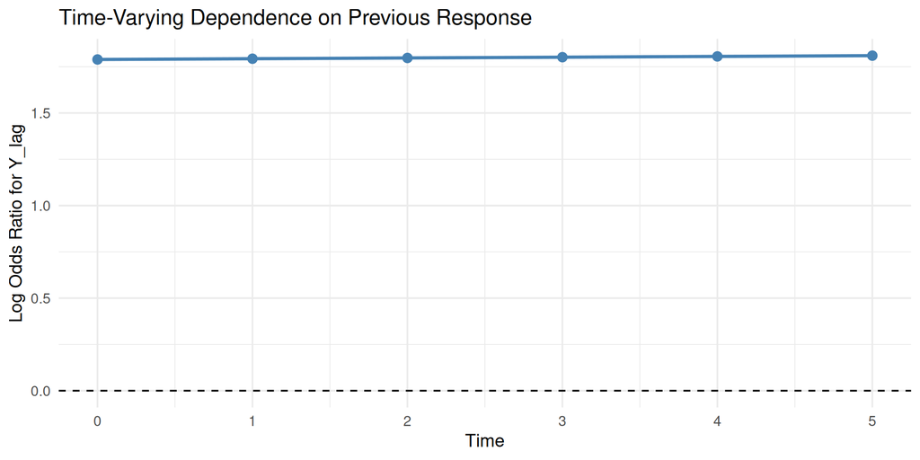

## Handling the Initial Observation

Three approaches for $Y_{i1}$:

| Approach | Description |
| --- | --- |
| **Condition on $Y_{i1}$** | Treat as fixed (most common) |
| **Model $Y_{i1}$ separately** | Specify marginal distribution |
| **Include random effects** | Joint model with shared $b_i$ |

Conditioning is simple and usually valid if $n_i$ is moderate.

## Part VI: Model Comparison

## Transition vs Marginal Models

| Aspect | Marginal (GEE) | Transition |
| --- | --- | --- |
| Conditions on | Covariates only | Covariates + past $Y$ |
| Correlation | Working $\operatorname{Corr}_i(\alpha)$ | Explicit via $Y_{j-1}$ |
| $\beta$ meaning | Population-average | Conditional on history |
| Use case | Population effects | State dependence |

## Transition vs Mixed Models

| Aspect | Mixed (GLMM) | Transition |
| --- | --- | --- |
| Conditions on | Random effects $b_i$ | Past responses |
| Heterogeneity | Unobserved traits | Observable history |
| Correlation source | Latent variable | Serial dependence |
| Computation | Integration required | Standard GLM |

## Same Data, Different Questions

```r
suppressPackageStartupMessages(library(lme4))

# Transition model (already fit)
# fit_trans

# Marginal model (GEE)
fit_marginal <- geeglm(y ~ trt + time,
                       data = dat_model,
                       id = id,
                       family = binomial,
                       corstr = "ar1")

# Mixed model (GLMM with random intercept)
fit_mixed <- glmer(y ~ trt + time + (1 | id),
                   data = dat_model,
                   family = binomial)

# Compare treatment effects
data.frame(
  Model = c("Transition", "Marginal (GEE)", "Mixed (GLMM)"),
  Estimate = c(coef(fit_trans)["trtTreatment"],
               coef(fit_marginal)["trtTreatment"],
               fixef(fit_mixed)["trtTreatment"]),
  SE = c(summary(fit_trans)$coefficients["trtTreatment", "Std. Error"],
         summary(fit_marginal)$coefficients["trtTreatment", "Std.err"],
         summary(fit_mixed)$coefficients["trtTreatment", "Std. Error"])
) |> mutate(across(where(is.numeric), ~round(., 3)))
```

## Same Data, Different Questions

```
           Model Estimate    SE
1     Transition   -0.541 0.152
2 Marginal (GEE)   -0.701 0.198
3   Mixed (GLMM)   -0.893 0.257
```

## Key Insight: Different Interpretations

**Transition:** Treatment effect on current response, **given previous response**

**Marginal:** Treatment effect on population-average probability

**Mixed:** Treatment effect for a specific subject (given $b_i$)

All are valid; choice depends on the research question.

## When Transition Models Excel

1. **Disease progression:** Natural states (remission/relapse)
2. **Panel surveys:** Employment, insurance status
3. **Clinical trials:** Response at each visit conditional on prior
4. **Process understanding:** Mechanism involves serial dependence

## Visualizing Trajectories

```r
# Sample 20 subjects
set.seed(667)
sample_ids <- sample(unique(dat$id), 20)

dat_sample <- dat |>
  filter(id %in% sample_ids)

ggplot(dat_sample, aes(time, y, group = id, color = trt)) +
  geom_line(alpha = 0.6) +
  geom_point(size = 1.5) +
  facet_wrap(~trt) +
  labs(title = "Individual Binary Trajectories",
       x = "Time", y = "Response (0/1)") +
  theme_minimal(base_size = 12) +
  theme(legend.position = "none")
```

## Visualizing Trajectories

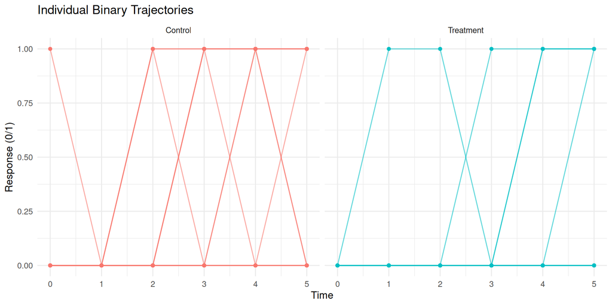

## Check Your Understanding: Part VI

**Quick Self-Check**

1. **Model Comparison:** A transition model gives treatment OR = 0.6; a marginal GEE gives OR = 0.7. Which is “correct”?
2. **Initial Observation:** You have 6 time points. When you fit a first-order transition model, how many observations per subject contribute to the likelihood?
3. **Choosing a Model:** You want to study how treatment affects the probability of relapse among cancer survivors. Which model type is most appropriate?

**Answers**

1. **Both are correct for different questions!** The transition model OR is conditional on previous state (“among those who were healthy last visit, treatment reduces odds of being sick by 40%”). The marginal OR is population-average (“overall, treatment reduces the odds of being sick by 30%”). They answer different questions.
2. **5 observations** - The first observation has no lag and is typically conditioned on (not modeled). The remaining 5 observations contribute to the conditional likelihood.
3. **Transition model** - The question explicitly involves a “state change” (relapse). Transition models naturally capture the probability of moving from remission to relapse, and can assess whether treatment modifies this transition probability.

## Common Mistakes in Transition Models

**Errors to Avoid**

| # | Mistake | Correct Approach |
| --- | --- | --- |
| 1 | Interpreting transition model $\beta$ as population-average | Transition $\beta$ is **conditional on previous state**; use GEE for population-average |
| 2 | Using non-independence working correlation | Once you include $Y_{j-1}$, use `corstr = "independence"` or robust SEs |
| 3 | Forgetting to remove first observation | First timepoint has no lag; filter to `!is.na(y_lag)` |
| 4 | Not testing higher-order dependence | Use LRT to compare first vs second-order models |
| 5 | Ignoring robust SEs | Always compute cluster-robust SEs; compare to model-based |
| 6 | Applying transition models to inappropriate outcomes | Best for discrete states with meaningful persistence (not continuous growth) |
| 7 | Confusing $\beta_1$ sign interpretation | $\beta_1 > 0$ = persistence; $\beta_1 < 0$ = alternation |
| 8 | Treating different models as competitors | Transition, marginal, and mixed models answer **different questions** |

**Golden Rule for Transition Models**

**The coefficient $\beta$ answers: “What is the effect of X on Y at time t, GIVEN that I know the state at time t-1?”**

This is fundamentally different from:

- Marginal models: “What is the effect of X on the average Y in the population?”
- Mixed models: “What is the effect of X on Y for a specific subject?”

All three can be valid; the choice depends on your scientific question.

## Summary

| Topic | Key Point |
| --- | --- |
| **Transition models** | Condition on previous responses |
| **Markov property** | Future depends on present, not full history |
| **Estimation** | Standard GLM with lagged response |
| **Interpretation** | Effect given past state |
| **Extensions** | Higher-order, time-varying dependence |
| **Comparison** | Different from marginal/mixed interpretations |

## Key Equations

**First-order transition model:**
$$\text{logit}\, P(Y_{ij} = 1 | Y_{i,j-1}, X_{ij}) = \beta_0 + \beta_1 Y_{i,j-1} + X_{ij}\gamma$$

**Transition probability:**
$$\pi_{jk} = P(Y_{ij} = 1 | Y_{i,j-1} = k)$$

**Odds ratio for state dependence:**
$$\text{OR}_{\text{lag}} = e^{\beta_1}$$

## Practical Recommendations

1. **Check for state dependence** before choosing a model
2. **Use robust SEs** (cluster or GEE) for valid inference
3. **Test higher-order terms** if theory suggests longer memory
4. **Compare with marginal/mixed** to understand different perspectives
5. **Report the conditioning** clearly when presenting results

## Course Wrap-Up

This completes the methods sequence. The three model families, all on one map:

- **Marginal** models (Ch. 12-13): population-average effects, GEE
- **Mixed** models (Ch. 8, 14): subject-specific effects, random effects $b_i$
- **Transition** models (instructor extension, FLW 1st-ed Ch. 10): effects conditional on past responses

Missing-data methods (MCAR/MAR/MNAR, multiple imputation, sensitivity analysis) were covered in the prior missing-data lectures. With transition models, you now have a complete toolkit for the three ways correlation enters longitudinal data.

## References

- Transition models are not a FLW 2nd-ed chapter. Source: Fitzmaurice, Laird & Ware (2004, 1st ed.), *Applied Longitudinal Analysis*, Ch. 10; the marginal/mixed/transition trichotomy is framed in FLW (2011, 2nd ed.) Ch. 12 (Marginal Models), which has no dedicated transition chapter.
- Diggle, Heagerty, Liang & Zeger (2002), *Analysis of Longitudinal Data*, Chapter 10
- Agresti (2013), *Categorical Data Analysis*, Chapter 12

## Appendix: Code Summary

```r
# Create lagged response
dat <- dat |>
  group_by(id) |>
  mutate(y_lag = lag(y, 1)) |>
  ungroup()

# Fit transition model
fit <- glm(y ~ y_lag + trt + time,
           data = dat,
           family = binomial)

# Robust standard errors
library(sandwich)
vcovCL(fit, cluster = dat$id)

# GEE alternative
library(geepack)
geeglm(y ~ y_lag + trt + time,
       id = id,
       family = binomial,
       corstr = "independence")
```